# HW 11 - GAMs

Keanu Rochette

2025-04-08

## Load libraries

```r
# Data manipulation and visualization
library(tidyverse)
library(here)
library(janitor)

# Data analysis/statistics
library(car) #ANOVA
library(ggResidpanel) #residual panel
library(ggeffects)
library(effects) #dependency for ggeffects
library(MuMIn)
library(gam)
library(mgcv)
```

## Load data

```r
FCM <- read_csv(here("HW11", "data", "HOT_cyto_counts.csv"))
MLDS <- read_csv(here("HW11", "data", "hot_mlds.csv"))

FCM <- clean_names(FCM)
MLDS <- clean_names(MLDS)
```

```r
# reformating the date and extracting the day of the year
# pressure turned negative for easier visualization later on
FCM <- FCM %>% mutate(cal_date = mdy(date)) %>% relocate(cal_date, .after= date) %>%
  mutate(doyear = yday(cal_date)) %>% relocate(doyear, .after= cal_date) %>%
  mutate(press = -1*press)
```

## Question 1

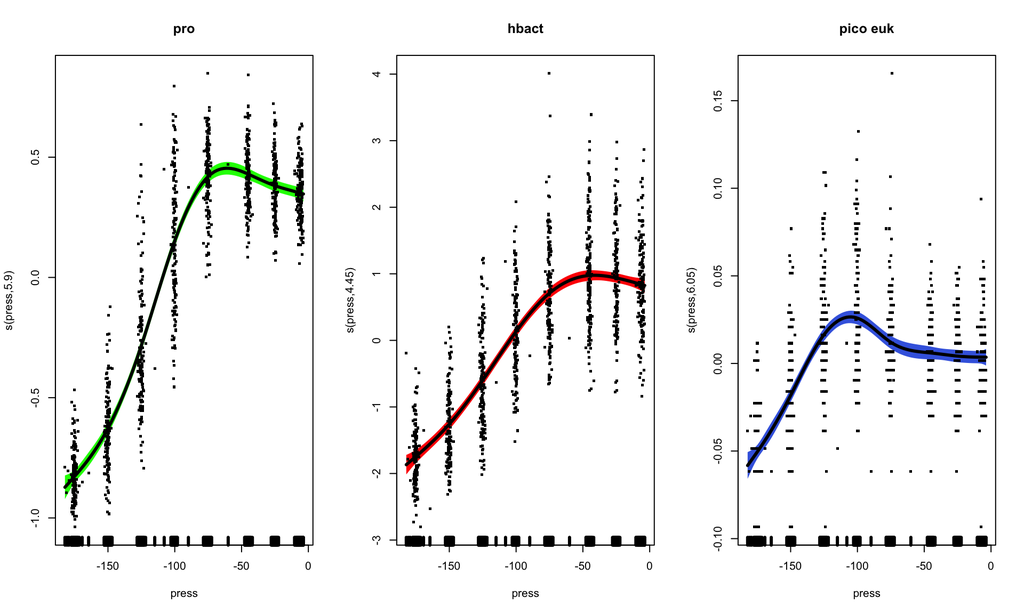

```r
# making models of the microbes as a fucntion of pressure only
proxdepth <- gam(sqrt(pro) ~ s(press), data= FCM)
hbactxdepth <- gam(hbact ~ s(press), data= FCM)
picoeukxdepth <- gam(sqrt(picoeuk)~ s(press), data= FCM)

par(mfrow = c(1,3))
plot(proxdepth, main = "pro", residuals = TRUE, cex = 4, lwd = 3, shade = TRUE, shade.col = "green")
plot(hbactxdepth, main = "hbact", residuals = TRUE, cex = 4, lwd = 3, shade = TRUE, shade.col = "red")
plot(picoeukxdepth, main= "pico euk", residuals = TRUE, cex = 4, lwd = 3, shade = TRUE, shade.col = "royalblue")
```

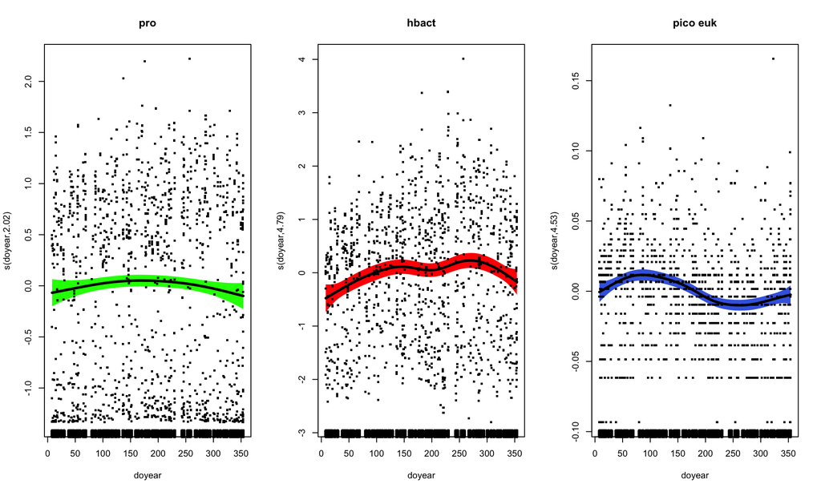

```r
# making models of the microbes as a fucntion of day of year only
proxday <- gam(pro ~ s(doyear), data= FCM)
hbactxday <- gam(hbact ~ s(doyear), data= FCM)
picoeukxday <- gam(sqrt(picoeuk)~ s(doyear), data= FCM)

par(mfrow = c(1,3))
plot(proxday, main = "pro", residuals = TRUE, cex = 4, lwd = 3, shade = TRUE, shade.col = "green")
plot(hbactxday, main = "hbact", residuals = TRUE, cex = 4, lwd = 3, shade = TRUE, shade.col = "red")
plot(picoeukxday, main = "pico euk", residuals = TRUE, cex = 4, lwd = 3, shade = TRUE, shade.col = "royalblue")
```

### Comprehesion models for each microbe

```r
# making the comprehensive model with pressure and day of year for prochlorococcus
pro2D <- gam(sqrt(pro) ~ s(doyear, press), data= FCM)
pro2D_X <- gam(sqrt(pro) ~ s(doyear) + s(press), data= FCM)
summary(pro2D)
```

```
##
## Family: gaussian
## Link function: identity
##
## Formula:
## sqrt(pro) ~ s(doyear, press)
##
## Parametric coefficients:
##             Estimate Std. Error t value Pr(>|t|)
## (Intercept) 1.037586   0.004633   223.9   <2e-16 ***
## ---
## Signif. codes:  0 '***' 0.001 '**' 0.01 '*' 0.05 '.' 0.1 ' ' 1
##
## Approximate significance of smooth terms:
##                   edf Ref.df     F p-value
## s(doyear,press) 27.39  28.84 375.4  <2e-16 ***
## ---
## Signif. codes:  0 '***' 0.001 '**' 0.01 '*' 0.05 '.' 0.1 ' ' 1
##
## R-sq.(adj) =  0.899   Deviance explained = 90.1%
## GCV = 0.026751  Scale est. = 0.026127  n = 1217
```

```r
anova(pro2D, pro2D_X)
```

```
## Analysis of Deviance Table
##
## Model 1: sqrt(pro) ~ s(doyear, press)
## Model 2: sqrt(pro) ~ s(doyear) + s(press)
##   Resid. Df Resid. Dev      Df Deviance      F    Pr(>F)
## 1    1187.2     31.055
## 2    1202.5     35.707 -15.339  -4.6524 11.609 < 2.2e-16 ***
## ---
## Signif. codes:  0 '***' 0.001 '**' 0.01 '*' 0.05 '.' 0.1 ' ' 1
```

#### Interpretation

The F value of the anova is significant which means that the interaction between depth and day of year explains the variation in abundance more than the variables alone.

```r
# making the comprehensive model with pressure and day of year for het bacteria
hbact2D <- gam(hbact ~ s(doyear, press), data= FCM)
hbact2D_X <- gam(hbact ~ s(doyear) + s(press), data= FCM)
summary(hbact2D)
```

```
##
## Family: gaussian
## Link function: identity
##
## Formula:
## hbact ~ s(doyear, press)
##
## Parametric coefficients:
##             Estimate Std. Error t value Pr(>|t|)
## (Intercept)  3.88022    0.01811   214.3   <2e-16 ***
## ---
## Signif. codes:  0 '***' 0.001 '**' 0.01 '*' 0.05 '.' 0.1 ' ' 1
##
## Approximate significance of smooth terms:
##                   edf Ref.df     F p-value
## s(doyear,press) 22.85  26.88 123.2  <2e-16 ***
## ---
## Signif. codes:  0 '***' 0.001 '**' 0.01 '*' 0.05 '.' 0.1 ' ' 1
##
## R-sq.(adj) =  0.732   Deviance explained = 73.7%
## GCV = 0.40709  Scale est. = 0.39911   n = 1217
```

```r
anova(hbact2D, hbact2D_X)
```

```
## Analysis of Deviance Table
##
## Model 1: hbact ~ s(doyear, press)
## Model 2: hbact ~ s(doyear) + s(press)
##   Resid. Df Resid. Dev     Df Deviance      F    Pr(>F)
## 1    1189.1     476.20
## 2    1201.9     524.42 -12.83   -48.22 9.4167 < 2.2e-16 ***
## ---
## Signif. codes:  0 '***' 0.001 '**' 0.01 '*' 0.05 '.' 0.1 ' ' 1
```

#### Interpretation

The F value of the anova is significant which means that the interaction between depth and day of year explains the variation in abundance more than the variables alone.

```r
# making the comprehensive model with pressure and day of year for pico eukaryotes
picoeuk2D <- gam(sqrt(picoeuk) ~ s(doyear, press), data= FCM)
picoeuk2D_X <- gam(sqrt(picoeuk) ~ s(doyear) + s(press), data= FCM)
summary(picoeuk2D)
```

```
##
## Family: gaussian
## Link function: identity
##
## Formula:
## sqrt(picoeuk) ~ s(doyear, press)
##
## Parametric coefficients:
##              Estimate Std. Error t value Pr(>|t|)
## (Intercept) 0.0933431  0.0006991   133.5   <2e-16 ***
## ---
## Signif. codes:  0 '***' 0.001 '**' 0.01 '*' 0.05 '.' 0.1 ' ' 1
##
## Approximate significance of smooth terms:
##                   edf Ref.df     F p-value
## s(doyear,press) 24.31  27.73 45.82  <2e-16 ***
## ---
## Signif. codes:  0 '***' 0.001 '**' 0.01 '*' 0.05 '.' 0.1 ' ' 1
##
## R-sq.(adj) =  0.514   Deviance explained = 52.3%
## GCV = 0.00060737  Scale est. = 0.00059474  n = 1217
```

```r
anova(picoeuk2D,picoeuk2D_X)
```

```
## Analysis of Deviance Table
##
## Model 1: sqrt(picoeuk) ~ s(doyear, press)
## Model 2: sqrt(picoeuk) ~ s(doyear) + s(press)
##   Resid. Df Resid. Dev      Df  Deviance      F    Pr(>F)
## 1    1188.3    0.70875
## 2    1200.0    0.77479 -11.746 -0.066037 9.4531 < 2.2e-16 ***
## ---
## Signif. codes:  0 '***' 0.001 '**' 0.01 '*' 0.05 '.' 0.1 ' ' 1
```

#### Interpretation

The F value of the anova is significant which means that the interaction between depth and day of year explains the variation in abundance more than the variables alone.

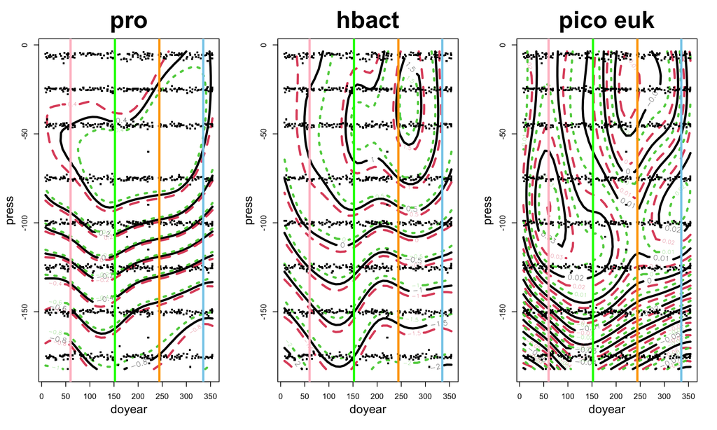

```r
par(mfrow = c(1,3))
plot(pro2D, main = "pro", residuals = TRUE, cex = 4, lwd = 3, cex.main = 3)
abline(v = 60, col = "pink",lwd = 3) #spring
abline(v = 152, col = "green",lwd = 3) #summer
abline(v = 244, col = "orange",lwd = 3) # fall
abline(v = 335, col = "skyblue",lwd = 3) # winter
plot(hbact2D, main = "hbact", residuals = TRUE, cex = 4, lwd = 3, cex.main = 3)
abline(v = 60, col = "pink",lwd = 3) #spring
abline(v = 152, col = "green",lwd = 3) #summer
abline(v = 244, col = "orange",lwd = 3) # fall
abline(v = 335, col = "skyblue",lwd = 3) # winter
plot(picoeuk2D, main = "pico euk", residuals = TRUE, cex = 4, lwd = 3, cex.main = 3)
abline(v = 60, col = "pink",lwd = 3) #spring
abline(v = 152, col = "green",lwd = 3) #summer
abline(v = 244, col = "orange",lwd = 3) # fall
abline(v = 335, col = "skyblue",lwd = 3) # winter
```

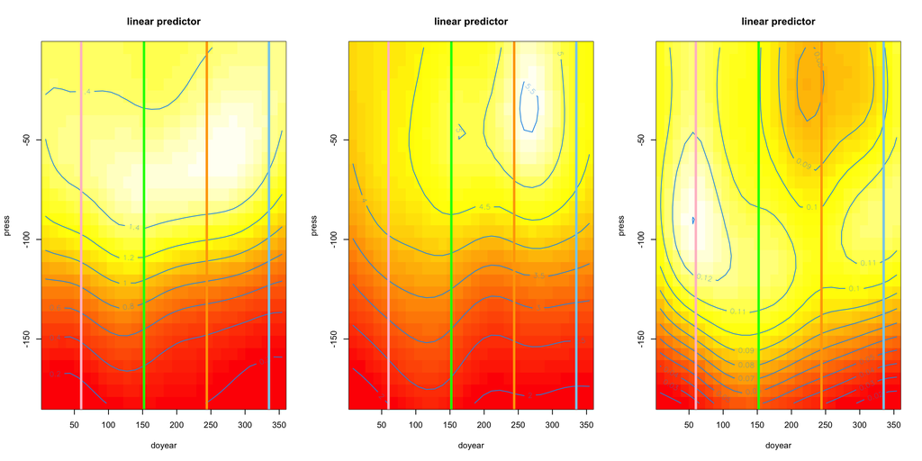

```r
par(mfrow = c(1,3))
vis.gam(pro2D, view = c("doyear", "press"), plot.type = "contour")
abline(v = 60, col = "pink",lwd = 3) #spring
abline(v = 152, col = "green",lwd = 3) #summer
abline(v = 244, col = "orange",lwd = 3) # fall
abline(v = 335, col = "skyblue",lwd = 3) # winter
vis.gam(hbact2D, view = c("doyear", "press"), plot.type = "contour")
abline(v = 60, col = "pink",lwd = 3) #spring
abline(v = 152, col = "green",lwd = 3) #summer
abline(v = 244, col = "orange",lwd = 3) # fall
abline(v = 335, col = "skyblue",lwd = 3) # winter
vis.gam(picoeuk2D, view = c("doyear", "press"), plot.type = "contour")
abline(v = 60, col = "pink",lwd = 3) #spring
abline(v = 152, col = "green",lwd = 3) #summer
abline(v = 244, col = "orange",lwd = 3) # fall
abline(v = 335, col = "skyblue",lwd = 3) # winter
```

## Question 2

```r
FCM_long <- FCM %>%
  pivot_longer(cols = hbact:picoeuk,
                     names_to = "microbe",
                     values_to = "micr_conc") %>%
  filter(microbe != "syn") %>%
  mutate(microbe = factor(microbe, levels= c("pro", "hbact", "picoeuk")))
```

### Setting up the model

```r
microbe_model <- gam(micr_conc ~ s(doyear, press, by = microbe) + microbe, data= FCM_long)
summary(microbe_model)
```

```
##
## Family: gaussian
## Link function: identity
##
## Formula:
## micr_conc ~ s(doyear, press, by = microbe) + microbe
##
## Parametric coefficients:
##                Estimate Std. Error t value Pr(>|t|)
## (Intercept)     1.33514    0.01210  110.36   <2e-16 ***
## microbehbact    2.54508    0.01711  148.75   <2e-16 ***
## microbepicoeuk -1.32520    0.01711  -77.45   <2e-16 ***
## ---
## Signif. codes:  0 '***' 0.001 '**' 0.01 '*' 0.05 '.' 0.1 ' ' 1
##
## Approximate significance of smooth terms:
##                                 edf Ref.df       F p-value
## s(doyear,press):microbepro     27.1  28.78 173.502  <2e-16 ***
## s(doyear,press):microbehbact   25.8  28.39 262.887  <2e-16 ***
## s(doyear,press):microbepicoeuk  2.0   2.00   0.013   0.987
## ---
## Signif. codes:  0 '***' 0.001 '**' 0.01 '*' 0.05 '.' 0.1 ' ' 1
##
## R-sq.(adj) =  0.947   Deviance explained = 94.8%
## GCV =  0.181  Scale est. = 0.17813   n = 3651
```

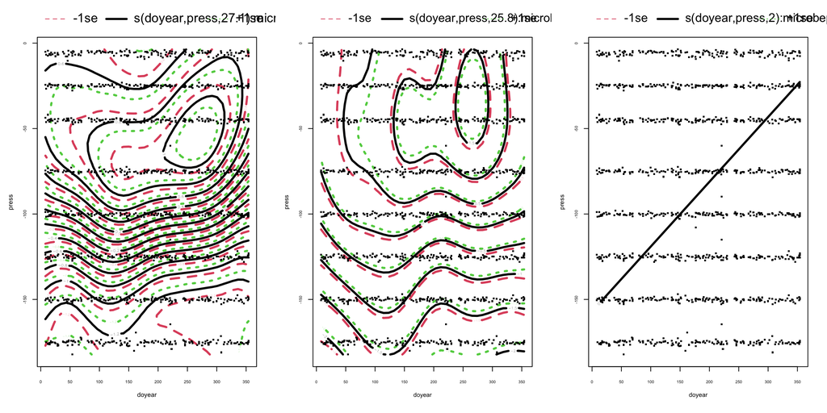

```r
# I don't know why my picoeukaryotes plot shows a linear trend instead of a contour plot...
par(mfrow = c(1,3))
plot(microbe_model, residuals = TRUE, cex = 4, lwd = 3, cex.main = 3)
```

### Interpretation

**(a) Do the different kinds of microbes have different mean abundances?**  
Yes, we saw that the estimated intercepts are different with the summary(microbe_model).

**(b) Do the different kinds of microbes have different average depth distributions (i.e., averaging over time)?**

```r
# we can compare the full model to a model in which only the depth (pressure) is accounted for in the variation of abundance of the microbes
microbe_depth <- gam(micr_conc ~ s(press, by = microbe) + microbe, data= FCM_long)
```

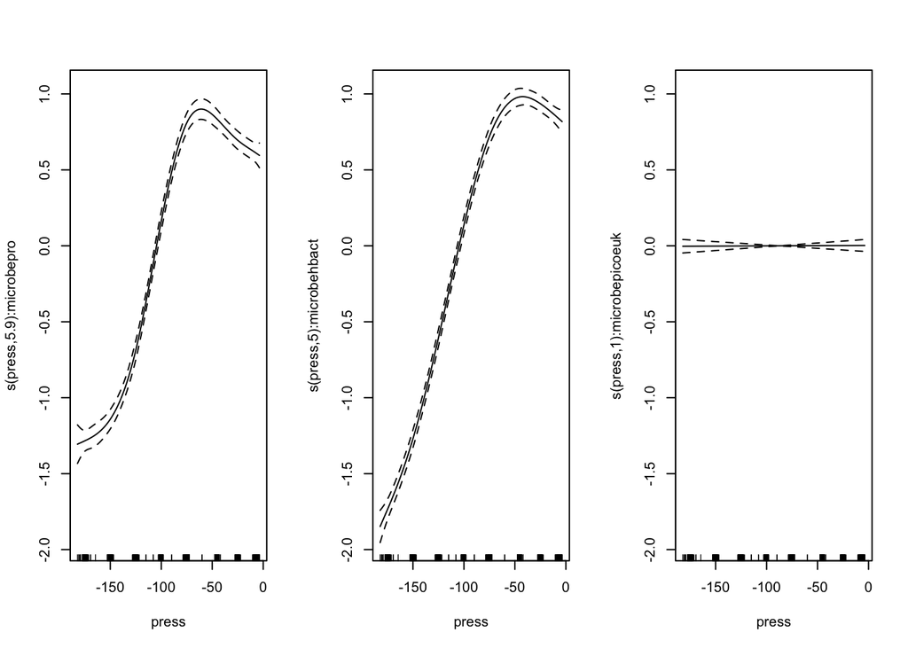

```r
par(mfrow = c(1,3))
plot(microbe_depth)
```

```r
# The F value of the anova is significant for pro and hbact which means that they are differently distributed on average by depth when averaging over time.
summary(microbe_depth)
```

```
##
## Family: gaussian
## Link function: identity
##
## Formula:
## micr_conc ~ s(press, by = microbe) + microbe
##
## Parametric coefficients:
##                Estimate Std. Error t value Pr(>|t|)
## (Intercept)     1.33514    0.01326  100.72   <2e-16 ***
## microbehbact    2.54508    0.01875  135.77   <2e-16 ***
## microbepicoeuk -1.32520    0.01875  -70.69   <2e-16 ***
## ---
## Signif. codes:  0 '***' 0.001 '**' 0.01 '*' 0.05 '.' 0.1 ' ' 1
##
## Approximate significance of smooth terms:
##                           edf Ref.df       F p-value
## s(press):microbepro     5.905  6.719 598.438  <2e-16 ***
## s(press):microbehbact   4.999  5.934 966.766  <2e-16 ***
## s(press):microbepicoeuk 1.000  1.000   0.015   0.904
## ---
## Signif. codes:  0 '***' 0.001 '**' 0.01 '*' 0.05 '.' 0.1 ' ' 1
##
## R-sq.(adj) =  0.936   Deviance explained = 93.7%
## GCV = 0.21471  Scale est. = 0.21383   n = 3651
```

**(c) Do the different kinds of microbes have different average seasonal dynamics (i.e., averaging over depths)**

```r
# we can make a model that only accounts for the day of the year as a predictor for the variation in microbe abundance
microbe_doyear <- gam(micr_conc ~ s(doyear, by = microbe) + microbe, data= FCM_long)
```

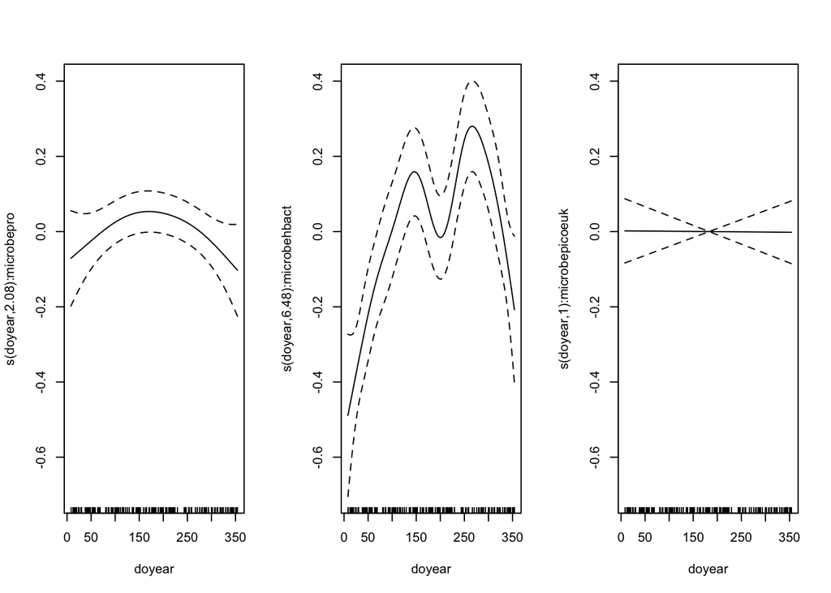

```r
par(mfrow = c(1,3))
plot(microbe_doyear)
```

```r
# the F value of the anova is only significant for hbact, which means that hetero trophic bacteria are distributed differently throughout the year.
summary(microbe_doyear)
```

```
##
## Family: gaussian
## Link function: identity
##
## Formula:
## micr_conc ~ s(doyear, by = microbe) + microbe
##
## Parametric coefficients:
##                Estimate Std. Error t value Pr(>|t|)
## (Intercept)     1.33514    0.02521   52.97   <2e-16 ***
## microbehbact    2.54508    0.03565   71.39   <2e-16 ***
## microbepicoeuk -1.32520    0.03565  -37.17   <2e-16 ***
## ---
## Signif. codes:  0 '***' 0.001 '**' 0.01 '*' 0.05 '.' 0.1 ' ' 1
##
## Approximate significance of smooth terms:
##                            edf Ref.df     F p-value
## s(doyear):microbepro     2.077  2.581 1.922   0.131
## s(doyear):microbehbact   6.485  7.617 8.084  <2e-16 ***
## s(doyear):microbepicoeuk 1.000  1.000 0.002   0.965
## ---
## Signif. codes:  0 '***' 0.001 '**' 0.01 '*' 0.05 '.' 0.1 ' ' 1
##
## R-sq.(adj) =   0.77   Deviance explained = 77.1%
## GCV = 0.77597  Scale est. = 0.7733    n = 3651
```

## Question 3

```r
MLDS<- MLDS %>% rename(cruise = crn)
```

```r
full_df <- left_join(FCM, MLDS, by = c("cruise", "date"))
```

```r
HOT <- full_df %>% select(-julian, -syn, -botid, -x1) %>%
  # we only want the data of the top 45m
  filter(press <=45) %>%
  filter(mean  <=45) %>%
  pivot_longer(cols = hbact:picoeuk,
                     names_to = "microbe",
                     values_to = "micr_conc") %>%
  mutate(microbe = factor(microbe, levels= c("pro", "hbact", "picoeuk"))) %>%
  rename(mixlay = mean)
```

### Mixed Layer

```r
#ML_gam <- gam(micr_conc ~ s(press, by = microbe)+ s(doyear, mixlay, by = microbe) + microbe, data = HOT)
ML_gam <- gam(micr_conc ~ s(mixlay, by = microbe) + microbe, data = HOT)
```

```r
summary(ML_gam)
```

```
##
## Family: gaussian
## Link function: identity
##
## Formula:
## micr_conc ~ s(mixlay, by = microbe) + microbe
##
## Parametric coefficients:
##                Estimate Std. Error t value Pr(>|t|)
## (Intercept)     1.36839    0.09561   14.31   <2e-16 ***
## microbehbact    2.47610    0.13521   18.31   <2e-16 ***
## microbepicoeuk -1.35897    0.13521  -10.05   <2e-16 ***
## ---
## Signif. codes:  0 '***' 0.001 '**' 0.01 '*' 0.05 '.' 0.1 ' ' 1
##
## Approximate significance of smooth terms:
##                            edf Ref.df     F  p-value
## s(mixlay):microbepro     1.000  1.000 0.042 0.837407
## s(mixlay):microbehbact   4.577  5.453 4.568 0.000433 ***
## s(mixlay):microbepicoeuk 1.000  1.000 0.000 0.996629
## ---
## Signif. codes:  0 '***' 0.001 '**' 0.01 '*' 0.05 '.' 0.1 ' ' 1
##
## Rank: 29/30
## R-sq.(adj) =  0.782   Deviance explained =   79%
## GCV = 0.75254  Scale est. = 0.72213   n = 237
```

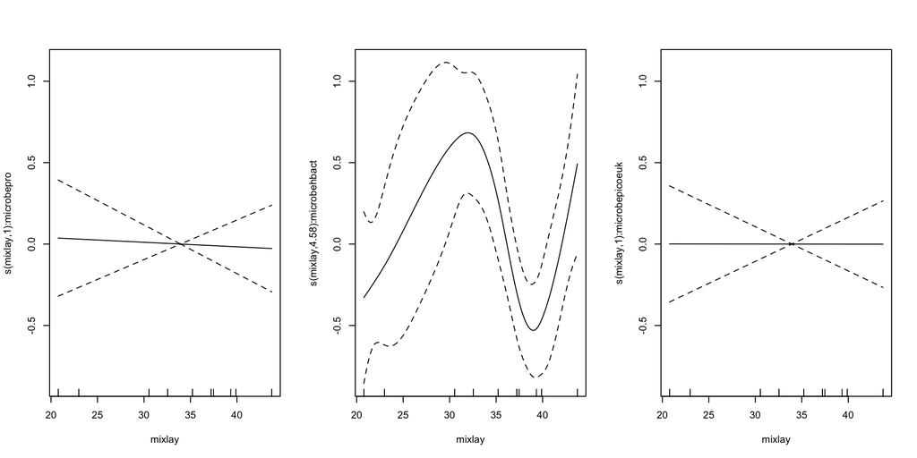

```r
par(mfrow = c(1,3))
plot(ML_gam)
```

#### Interpretation

We can see that the heterotrophic bacteria are significantly associated with the variation in mixed layer depth. There is a peak of hbact abundance around 32m and a low in hbact abundance at 39m.

### Chlorophyll

```r
chl_gam <- gam(micr_conc ~ s(chl, by = microbe) + microbe, data = HOT)
```

```r
summary(chl_gam)
```

```
##
## Family: gaussian
## Link function: identity
##
## Formula:
## micr_conc ~ s(chl, by = microbe) + microbe
##
## Parametric coefficients:
##                Estimate Std. Error t value Pr(>|t|)
## (Intercept)     1.40333    0.09019   15.56   <2e-16 ***
## microbehbact    2.56013    0.12755   20.07   <2e-16 ***
## microbepicoeuk -1.39299    0.12755  -10.92   <2e-16 ***
## ---
## Signif. codes:  0 '***' 0.001 '**' 0.01 '*' 0.05 '.' 0.1 ' ' 1
##
## Approximate significance of smooth terms:
##                         edf Ref.df     F  p-value
## s(chl):microbepro     3.895  4.825 4.976 0.000385 ***
## s(chl):microbehbact   7.952  8.711 5.825 1.46e-06 ***
## s(chl):microbepicoeuk 1.000  1.000 0.003 0.959428
## ---
## Signif. codes:  0 '***' 0.001 '**' 0.01 '*' 0.05 '.' 0.1 ' ' 1
##
## R-sq.(adj) =  0.834   Deviance explained = 84.6%
## GCV = 0.61587  Scale est. = 0.56939   n = 210
```

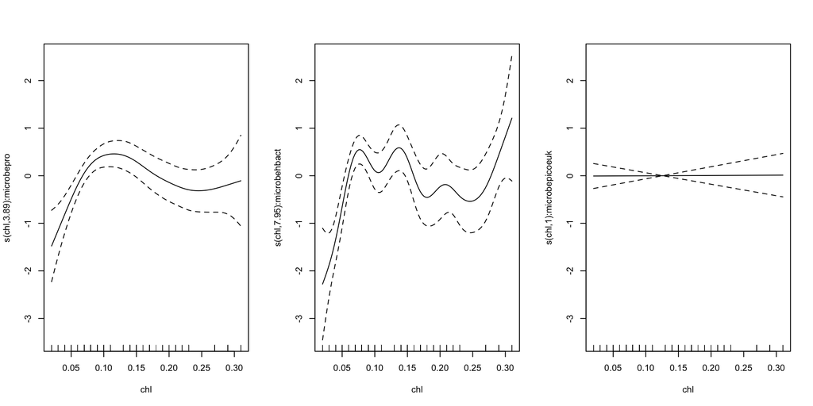

```r
par(mfrow = c(1,3))
plot(chl_gam)
```